# Transgressive segregation in mean phenotype

Keisuke Atsumi

19/12/04 22:58

# Exploring frequency of transgressive segregation and it affecting factors

```r
> dat.full <- read.csv("../data/mean.ES.TS.csv", head = TRUE) %>%
+   # Assign overdoinance to 1, no TS to 0 for each effect size
+   mutate(TS = ifelse(SMD.es < 0, 1, 0)) %>%
+   ### Join with metadata ###
+   left_join(
+     .,
+     read.xlsx(
+       "../data/original.data.xlsx", sheet = "Metadata"
+       )
+     ) %>%
+   mutate_at(vars(divergence.cytb:surv.relat.hyb21), as.numeric) %>%
+   mutate_at(
+     vars(contains("divergence"), contains("surv.relat")), scale
+     ) %>%
+   as.data.frame %>%
+   select(-trait) %>%
+   mutate_at("taxa", as.factor) %>%
+   within(levels(TS) <- c("No", "Transgressive segregation")) %>%
+   within(
+     taxa <- ordered(
+       taxa,
+       levels = c(
+         "Teleost", "Amphibian", "Bird", "Mammal",
+         "Diptera", "Lepidoptera", "Neuroptera",
+         "Orthoptera","Coleoptera"
+         )
+       )
+     ) %>%
+   drop_na(hetero.sex, pheno.div.diff, trait.type, divergence.COI) %>%
+   # Insect or no
+   mutate(
+     insect = ifelse(taxa %in% c("Teleost", "Amphibian", "Bird", "Mammal"), "no", "insect"),
+   )
>
>
> #### Phylogenetic tree for mcmcglmm ####
>
> # compute branch lengths of tree
> phylo_branch <- read.tree(file = "../data/phylo.mean.TS.tre") %>%
+   compute.brlen(bin.tree, method = "Grafen", power = 1)
>
> # saving phylogeneic matrix
> phylo_cor <- vcv(phylo_branch, cor = T)
>
> # generating inverse phylogenetic matrix for MCMCglmm
> # Note one of the tips is called "Lates calcarifer (estimated)"
> phylo_branch$node.label <- NULL
> phylo_MCMC <- MCMCglmm::inverseA(phylo_branch, nodes = "ALL", scale = TRUE)$Ainv
```

# Frequency of TS

How frequent the TS is?

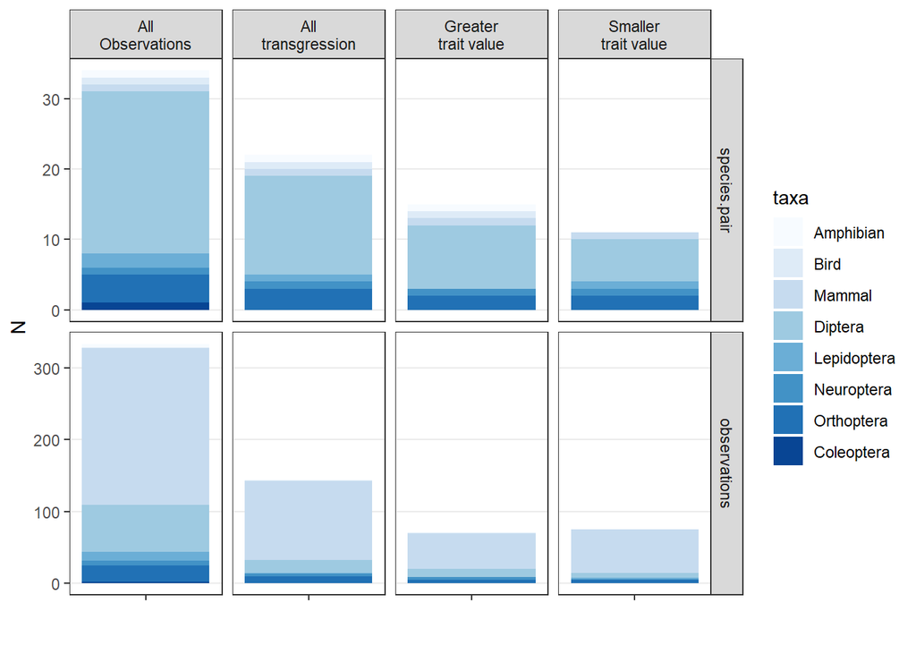

```r
> # TS.ES <- TS %>% filter(TS == "1") %>%
> #   distinct(ES.ID)
> # noTS <- TS %>%
> #   filter(!ES.ID %in% TS.ES$ES.ID) %>%
> #   distinct(ES.ID, .keep_all = TRUE)
>
> ### N of TS in each taxa and each direction ###
> summary <- bind_rows(
+   # All observations
+   dat.full %>%
+     group_by(taxa) %>%
+     summarise(
+       species.pair = length(unique(species.pair)),
+       observations = length(unique(ES.ID)),
+       study = length(unique(Study.ID))
+       ) %>%
+     mutate(direction = "All Observations")
+   ,
+   # TS for any direction
+   dat.full %>%
+     filter(TS == "1") %>%
+     group_by(taxa) %>%
+     summarise(
+       species.pair = length(unique(species.pair)),
+       observations = length(unique(ES.ID)),
+       study = length(unique(Study.ID))
+       ) %>%
+     mutate(direction = "Any directions")
+   ,
+   # TS for each direction
+   dat.full %>%
+     filter(TS == "1") %>%
+     group_by(taxa, direction) %>%
+     summarise(
+       species.pair = length(unique(species.pair)),
+       observations = length(unique(ES.ID)),
+       study = length(unique(Study.ID))
+       )
+   ) %>%
+   # Assign 0 for no observation of TS
+   replace(., is.na(.), "0") %>%
+   # Make tidy data
+   gather(key = metrics, value = N, -c(taxa, direction)) %>%
+   # Order factors
+   mutate_at(vars("metrics", "direction"), as.factor) %>%
+   # Order taxon
+   within(
+     metrics <- ordered(
+       metrics,
+       levels = c("study", "species.pair", "observations")
+       )
+   ) %>%
+   # Order TS category
+   within(
+     direction <- ordered(
+       direction,
+       levels = c("All Observations", "Any directions", "+", "-")
+       )
+     ) %>%
+   # Change names of TS category to more intuitive name
+   within(
+     levels(direction) <- c("All Observations", "All transgression", "Greater trait value", "Smaller trait value")
+       ) %>%
+   filter(metrics != "study")
>
> ### Plot ###
> plot <- ggplot(summary, aes(x = "", y = N, fill = taxa)) +
+   geom_bar(width = 1, stat = "identity") +
+   scale_fill_brewer() +
+   facet_grid(
+     scale = "free", metrics ~ direction,
+     # strip text into two lines
+     labeller = label_wrap_gen(width = 13)
+     ) +
+   xlab("") +
+   theme_bw() +
+   theme(
+     panel.grid.minor = element_blank(),
+     panel.grid.major.x = element_blank(),
+   )
> plot
```

```r
> ggsave(plot = plot, file = "../Analysis/mean.TS.frequency.svg", height = 4, width = 6)
>
> ### Total number of observations and percentage ###
> summary %>%
+   group_by(direction, metrics) %>%
+   # Count number of observaitons and species pairs
+   summarise(sum(N)) %>%
+   spread(key = metrics, value = "sum(N)") %>%
+   as.data.frame() %>%
+   # Calculate percentage
+   mutate(
+     percent.species.pair = species.pair/.[1, "species.pair"]*100,
+     percent.observations = observations/.[1, "observations"]*100
+   ) %>%
+   mutate_at(vars(contains("percent")), round, 2) %>%
+   kable("html", digits = 3) %>% kable_styling("striped", position = "left")
```

| direction | species.pair | observations | percent.species.pair | percent.observations |
| --- | --- | --- | --- | --- |
| All Observations | 34 | 334 | 100.00 | 100.00 |
| All transgression | 22 | 144 | 64.71 | 43.11 |
| Greater trait value | 15 | 71 | 44.12 | 21.26 |
| Smaller trait value | 11 | 75 | 32.35 | 22.46 |

# Seeking factor influences the frequency of TS

Previous study (Stelkens et al 2009 Evolution) showed TS in F1 become frequent as parental species diverges in plant. How about male sexual traits in animals?  
Does TS biased toward larger phenotypic value? -> *parentalspS* will negative  
Does TS biased toward father species? -> *patmatmother* will negative

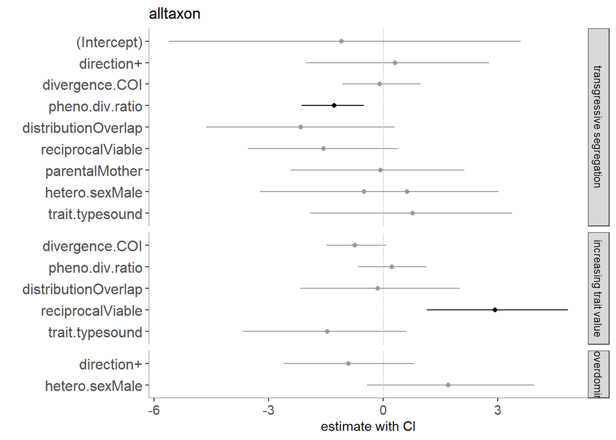

```
                       group             factors  Mean   SD pMCMC significance
1  transgressive segregation         (Intercept) -1.10 2.39 0.631
2  transgressive segregation      parentalMother -0.08 1.16 0.951
3  transgressive segregation      hetero.sexMale -0.51 1.47 0.727
4  transgressive segregation          direction+  0.31 1.24 0.791
5  transgressive segregation      divergence.COI -0.10 0.51 0.858
6  transgressive segregation     pheno.div.ratio -1.29 0.42 0.000            *
7  transgressive segregation     trait.typesound  0.77 1.35 0.571
8  transgressive segregation distributionOverlap -2.17 1.27 0.081
9  transgressive segregation    reciprocalViable -1.57 1.01 0.115
10       polar overdominance      hetero.sexMale  1.70 1.13 0.133
11       polar overdominance          direction+ -0.91 0.88 0.300
12    increasing trait value      divergence.COI -0.75 0.40 0.061
13    increasing trait value     pheno.div.ratio  0.23 0.45 0.609
14 transgressive segregation      hetero.sexMale  0.62 1.27 0.623
15    increasing trait value     trait.typesound -1.47 1.08 0.168
16    increasing trait value distributionOverlap -0.15 1.06 0.907
17    increasing trait value    reciprocalViable  2.92 0.95 0.003            *

Iterations = 5001:59991
Thinning interval = 10
Number of chains = 1
Sample size per chain = 5500

1. Empirical mean and standard deviation for each variable,
   plus standard error of the mean:

           Mean     SD Naive SE Time-series SE
Study.ID  2.320  3.402  0.04587         0.5625
Cross.ID  1.170  1.575  0.02124         0.1503
spL.name 24.496 23.943  0.32284         3.4730
SE.units 80.076 32.871  0.44324        10.4993
units     0.743  0.000  0.00000         0.0000

2. Quantiles for each variable:

              2.5%     25%     50%    75%   97.5%
Study.ID  0.002896  0.2731  1.0525  2.857  12.683
Cross.ID  0.001629  0.1516  0.5639  1.555   5.600
spL.name  0.286744  7.6034 17.4280 34.005  86.215
SE.units 23.280431 58.7622 78.3485 95.915 154.152
units     0.743029  0.7430  0.7430  0.743   0.743
```

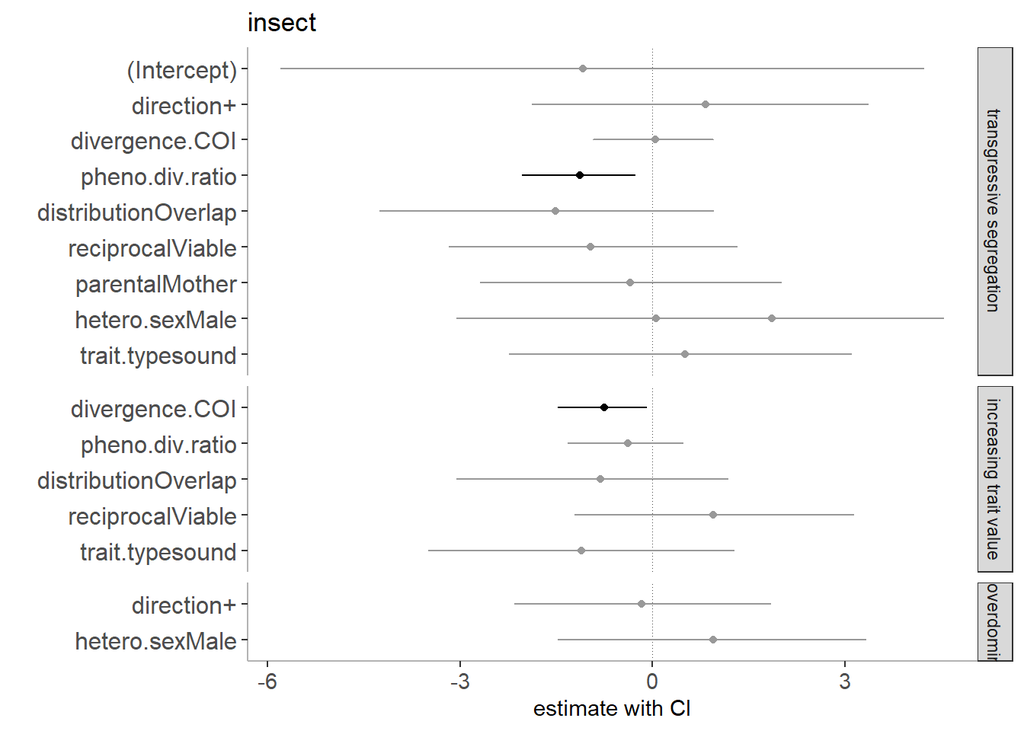

```
                       group             factors  Mean   SD pMCMC significance
1  transgressive segregation         (Intercept) -1.08 2.59 0.640
2  transgressive segregation      parentalMother -0.35 1.20 0.774
3  transgressive segregation      hetero.sexMale  0.05 1.58 0.981
4  transgressive segregation          direction+  0.82 1.36 0.560
5  transgressive segregation      divergence.COI  0.04 0.48 0.881
6  transgressive segregation     pheno.div.ratio -1.13 0.45 0.003            *
7  transgressive segregation     trait.typesound  0.50 1.36 0.704
8  transgressive segregation distributionOverlap -1.51 1.31 0.236
9  transgressive segregation    reciprocalViable -0.96 1.13 0.355
10       polar overdominance      hetero.sexMale  0.95 1.23 0.441
11       polar overdominance          direction+ -0.17 1.00 0.836
12    increasing trait value      divergence.COI -0.75 0.36 0.028            *
13    increasing trait value     pheno.div.ratio -0.38 0.46 0.400
14 transgressive segregation      hetero.sexMale  1.86 1.37 0.174
15    increasing trait value     trait.typesound -1.10 1.23 0.361
16    increasing trait value distributionOverlap -0.81 1.06 0.433
17    increasing trait value    reciprocalViable  0.95 1.11 0.366

Iterations = 5001:59991
Thinning interval = 10
Number of chains = 1
Sample size per chain = 5500

1. Empirical mean and standard deviation for each variable,
   plus standard error of the mean:

           Mean     SD Naive SE Time-series SE
Study.ID  3.420  6.913  0.09322         0.9678
Cross.ID  2.081  3.088  0.04164         0.4552
spL.name 30.005 49.550  0.66813        10.8092
SE.units 79.783 84.742  1.14267        34.3533
units     0.743  0.000  0.00000         0.0000

2. Quantiles for each variable:

             2.5%    25%     50%     75%   97.5%
Study.ID 0.004354 0.3820  1.3685   3.571  21.179
Cross.ID 0.002372 0.2031  0.8224   2.636  11.142
spL.name 0.134252 3.4870 10.9569  32.939 169.873
SE.units 0.147705 9.0100 43.0198 141.052 277.158
units    0.743029 0.7430  0.7430   0.743   0.743
```

```r
> for (k in c("alltaxon", "insect")) {
+
+   if (k == "alltaxon") {
+     dat <- dat.full
+   } else {
+     dat <- dat.full %>%
+       filter(insect == k)
+   }
+
+   # ### Setting prior to logistic regression ###
+   # prior <- list(
+   #   B=list(
+   #     mu = rep(0, 17), # N of coefficient. (level -1) for categorical factors, 1 for continuous factors, 1 for intercept
+   #     V = gelman.prior(~
+   #       parental*hetero.sex +
+   #       parental*direction +
+   #       direction*divergence.COI + direction*pheno.div.ratio +
+   #       direction*hetero.sex +
+   #       direction*trait.type +
+   #       direction*distribution + direction*reciprocal,
+   #     data = dat, # formula and data
+   #     scale=sqrt(pi^2/3+1))), # error distribution of logistic regression
+   #   R=list(V=1,fix=1),
+   #   G = list(
+   #     G1 = list(V = 1, nu = 1, alpha.mu = 0, alpha.V = 1000),
+   #     G2 = list(V = 1, nu = 1, alpha.mu = 0, alpha.V = 1000),
+   #     G3 = list(V = 1, nu = 1, alpha.mu = 0, alpha.V = 1000),
+   #     G4 = list(V = 1, nu = 1, alpha.mu = 0, alpha.V = 1000)
+   #     )
+   #   )
+   # ## Phylogenetic binomial regression ###
+   # phylmix <-MCMCglmm(
+   #   fixed = TS ~
+   #     parental*hetero.sex + parental*direction +
+   #     direction*divergence.COI + direction*pheno.div.ratio +
+   #     direction*hetero.sex + direction*trait.type +
+   #     direction*distribution + direction*reciprocal,
+   #   # idh(SE):units | weight by SE of effect size
+   #   random = ~ Study.ID + Cross.ID + spL.name + idh(SE):units,
+   #   family = "categorical",
+   #   verbose = FALSE,
+   #   ginverse = list(spL.name = phylo_MCMC),
+   #   prior = prior,
+   #   data = dat,
+   #   nitt = 60000,  # Increase the number of iterations, default is 13000
+   #   burnin = 5000  # Increase the number of burnin, default is 3000
+   # )
+   # phylmix$Sol <- phylmix$Sol/sqrt(1+c2)
+   # ### Save model ###
+   # saveRDS(phylmix, file = paste("../Analysis/Mean.transgression.allfactors", k, "obj", sep = "."))
+
+
+ ### Load model ###
+ phylmix <- readRDS(paste("../Analysis/Mean.transgression.allfactors", k, "obj", sep = "."))
+
+ sum <- left_join(
+   # corrected estimates & SD
+   summary(phylmix$Sol)$statistics %>%
+     as.data.frame() %>%
+     rownames_to_column(var = "factors"),
+   # P
+   summary(phylmix)$solutions %>%
+   as.data.frame() %>%
+     rownames_to_column(var = "factors"),
+   by = "factors"
+   ) %>%
+   mutate(significance = ifelse(pMCMC < 0.05, "*", "")) %>%
+   ### Grouping factors ###
+   mutate(
+     group = ifelse(str_detect(factors, "direction.:"),
+                    "increasing trait value",
+                    ifelse(str_detect(factors, "parentalMother:"),
+                           "polar overdominance",
+                           ifelse(factors == "hetero.sexmale:direction+",
+                                  "increasing trait value",
+                                  "transgressive segregation"
+                                  )
+                           )
+                    )
+   ) %>%
+   mutate_at("group", as.factor) %>%
+   within(group <- ordered(group, c("transgressive segregation", "increasing trait value", "polar overdominance"))) %>%
+   ### Change factor names ###
+   within(
+     factors <- str_remove_all(
+       factors, "direction.:"
+       ) %>%
+       str_remove_all(., "parentalMother:") %>%
+       str_remove_all(., ":direction.")
+     ) %>%
+   within(
+     factors <- factor(
+       factors, ordered = TRUE,
+       levels = c("trait.typesound", "hetero.sexMale", "parentalMother", "reciprocalViable", "distributionOverlap", "pheno.div.ratio", "sq.divergence.COI", "divergence.COI",  "direction+", "(Intercept)")
+       )
+     )
+
+
+ ### Plot ###
+ metaplot <- ggplot(sum, aes(
+   x = post.mean,
+   # Inverse order of factors
+   y = factors
+   )) +
+   # Vertical line
+   geom_vline(
+     xintercept = 0, size = 0.3,
+     colour = "grey30", linetype = "dotted"
+     ) +
+   # CI
+   geom_errorbarh(
+     aes(
+       xmin = sum[, 'l-95% CI'], xmax = sum[, 'u-95% CI'],
+       colour=significance
+       ),
+     height = .0001
+     ) +
+   # Color of plots and errorbars
+   scale_colour_manual(values = c("grey60", "black")) +
+   geom_point(size = 1.5, aes(colour = significance)) +
+   scale_fill_manual(values = c("grey60", "black")) +
+   # Title
+   ggtitle(k) +
+   ylab("") + xlab("estimate with CI") +
+   # Combine different plots for main factors and interactions
+   facet_grid(group~., scales = "free", space = "free") +
+   # Themes
+   theme_bw() +
+   theme(
+     panel.grid = element_blank(),
+     legend.position = "none",
+     panel.border=element_blank(),
+     axis.text.x = element_text(size = 11),
+     axis.text.y = element_text(size = 12),
+     axis.line=element_line(colour = "grey70")
+     )
+ print(metaplot)
+
+ ggsave(
+     plot = metaplot,
+     file = "../Analysis/mean.TS.result.svg",
+     height = 6.75, width = 4.5
+     )
+
+ ### Output result ###
+
+
+   sum %>%
+     select(group, factors, Mean, SD, pMCMC, significance) %>%
+     mutate_at(c("Mean", "SD"), round, 2) %>%
+     mutate_at(c("pMCMC"), round, 3) %>%
+     print()
+
+   # transformation for estimate
+   # summary(phylmix$Sol/sqrt(1+c2))
+   # transformation for varaince
+   summary(phylmix$VCV/(1+c2)) %>%
+     print()
+
+ }
```

```r
> rawdat <- dat.full %>%
+   select(-pheno.div.ratio, -divergence.COI) %>%
+   # lnRR between parental species as phenotypic distance
+   mutate(pheno.div.ratio = log(Mn.spL/Mn.spS)) %>%
+   left_join(
+     .,
+     read.xlsx(
+       "../data/original.data.xlsx", sheet = "Metadata"
+       ) %>%
+       select(Cross.ID, divergence.COI)
+     ) %>%
+   # Natural log of genetic distance
+   mutate_at("divergence.COI", log)
>
>
> fit = glm(
+   TS ~ divergence.COI*direction,
+   data = rawdat,
+   family = binomial
+   )
> ggPredict(fit, se = TRUE, interactive = TRUE, digits = 3)
```

[interactive chart not shown]

```r
> fit = glm(
+   TS ~ pheno.div.ratio*direction,
+   data = rawdat %>%
+     mutate_at("divergence.COI", as.vector),
+   family = binomial
+   )
> ggPredict(fit, se=TRUE, interactive = TRUE, digits = 3)
```

[interactive chart not shown]

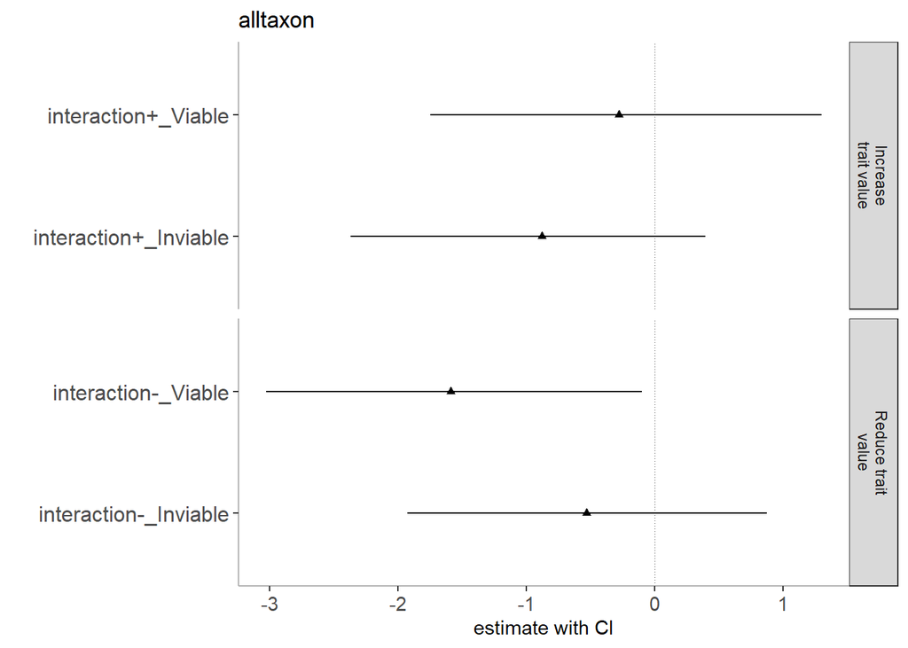

```r
> for (i in c("reciprocal", "trait.type")) {
+   for (k in c("alltaxon", "insect")) {
+
+     if (k == "alltaxon") {
+       dat <- dat.full
+     } else {
+       dat <- dat.full %>%
+         filter(insect == k)
+     }
+
+     # Make new categorical data combining direction of TS and target categorical factor
+     dat %<>%
+       mutate(interaction = str_c(direction, .[, i], sep = "_"))
+
+
+     # ### Setting prior to logistic regression ###
+     # prior <- list(
+     #   B=list(
+     #     mu = rep(0, 4), # N of coefficient. (level -1) for categorical factors, 1 for continuous factors, 1 for intercept
+     #     V = gelman.prior(~ interaction, # + trait.direction
+     #     data = dat, # formula and data
+     #     scale=sqrt(pi^2/3+1))), # error distribution of logistic regression
+     #   R=list(V=1,fix=1),
+     #   # Replicating same G for the number of random effects (here, 4)
+     #   G = list(
+     #     G1 = list(V = 1, nu = 1, alpha.mu = 0, alpha.V = 1000),
+     #     G2 = list(V = 1, nu = 1, alpha.mu = 0, alpha.V = 1000),
+     #     G3 = list(V = 1, nu = 1, alpha.mu = 0, alpha.V = 1000),
+     #     G4 = list(V = 1, nu = 1, alpha.mu = 0, alpha.V = 1000)
+     #     )
+     #   )
+     #
+     # phylmix <-MCMCglmm(
+     #   fixed = TS ~  interaction -1, # + trait.direction
+     #   family = "categorical",
+     #   # idh(SE):units | weight by SE of effect size
+     #   random = ~ Study.ID + Cross.ID + spL.name + idh(SE):units,
+     #   verbose = FALSE,
+     #   ginverse = list(spL.name = phylo_MCMC),
+     #   prior = prior,
+     #   data = dat
+     # )
+     # # Correct model result
+     # phylmix$Sol <- phylmix$Sol/sqrt(1+c2)
+     # ### Save model ###
+     # saveRDS(
+     #   phylmix,
+     #   file =
+     #     paste("../Analysis/Mean.transgression", i,k, "obj", sep = ".")
+     #     )
+
+
+
+     ### Load model ###
+     phylmix <- readRDS(
+       paste("../Analysis/Mean.transgression", i,k, "obj", sep = ".")
+       )
+
+     sum <- left_join(
+       # corrected estimates & SD
+       summary(phylmix$Sol)$statistics %>%
+         as.data.frame() %>%
+         rownames_to_column(var = "factors"),
+       # P
+       summary(phylmix)$solutions %>%
+       as.data.frame() %>%
+       rownames_to_column(var = "factors"),
+       by = "factors"
+       ) %>%
+       mutate(
+         significance = ifelse(pMCMC < 0.05, "*", ""),
+         direction =
+           ifelse(str_detect(factors, "\\+"), "Increase trait value",
+                  ifelse(str_detect(factors, "\\-"), "Reduce trait value",
+                         ifelse(str_detect(factors, "Father_"), "Exceed father trait value", "Exceed mother trait value")
+                         )
+                  )
+         )
+
+     ### Plot ###
+     categoricalplot <- ggplot(
+       sum, aes(x = post.mean, y = factors)
+       ) +
+       # Vertical line
+       geom_vline(
+         xintercept = 0, size = 0.3,
+         colour = "grey30", linetype = "dotted"
+         ) +
+       # CI
+       geom_errorbarh(
+         aes(
+           xmin = sum[, 'l-95% CI'],
+           xmax = sum[, 'u-95% CI'],
+           ),
+         height = .0001
+         ) +
+       geom_point(size = 1.5, shape = 17) +
+       # Title
+       ylab("") + xlab("estimate with CI") +
+       ggtitle(k) +
+       # Combine different plots for main factors and interactions
+       # Themes
+       theme_bw() +
+       # Combine different plots for main factors and interactions
+       facet_grid(
+         direction ~., scales = "free", drop = TRUE,
+         labeller = label_wrap_gen(width = 13)
+         ) +
+       theme(
+         panel.grid = element_blank(),
+         legend.position = "none",
+         panel.border = element_blank(),
+         axis.text.x = element_text(size = 11),
+         axis.text.y = element_text(size = 12),
+         axis.line=element_line(colour = "grey70")
+         )
+     print(categoricalplot)
+
+     ggsave(
+         plot = categoricalplot,
+         file =
+             paste("../Analysis/Mean.TS.categorical", i,k, "svg", sep = "."),
+         height = 6, width = 5
+         )
+
+   #####################################
+   # Contrast
+   #####################################
+
+   bind_rows(
+     HPDinterval(phylmix$Sol[,1] - phylmix$Sol[,2]) %>%
+       as.data.frame() %>%
+       mutate(
+         from = row.names(summary(phylmix)$solutions)[1],
+         to = row.names(summary(phylmix)$solutions)[2]
+         ),
+     HPDinterval(phylmix$Sol[,1] - phylmix$Sol[,3]) %>%
+       as.data.frame() %>%
+       mutate(
+         from = row.names(summary(phylmix)$solutions)[1],
+         to = row.names(summary(phylmix)$solutions)[3]
+         ),
+     HPDinterval(phylmix$Sol[,1] - phylmix$Sol[,4]) %>%
+       as.data.frame() %>%
+       mutate(
+         from = row.names(summary(phylmix)$solutions)[1],
+         to = row.names(summary(phylmix)$solutions)[4]
+         ),
+     HPDinterval(phylmix$Sol[,2] - phylmix$Sol[,3]) %>%
+       as.data.frame() %>%
+       mutate(
+         from = row.names(summary(phylmix)$solutions)[2],
+         to = row.names(summary(phylmix)$solutions)[3]
+         ),
+     HPDinterval(phylmix$Sol[,2] - phylmix$Sol[,4]) %>%
+       as.data.frame() %>%
+       mutate(
+         from = row.names(summary(phylmix)$solutions)[2],
+         to = row.names(summary(phylmix)$solutions)[4]
+         ),
+     HPDinterval(phylmix$Sol[,3] - phylmix$Sol[,4]) %>%
+       as.data.frame() %>%
+       mutate(
+         from = row.names(summary(phylmix)$solutions)[3],
+         to = row.names(summary(phylmix)$solutions)[4]
+         )
+     ) %>%
+     as.data.frame() %>%
+     mutate(
+       sign = ifelse((upper < 0), "-", ifelse(lower > 0, "+", ""))
+       ) %>%
+     mutate_at(
+       vars("from", "to"),
+       funs(
+         str_replace_all(., pattern = "interaction", replacement = "direction")
+         )
+       ) %>%
+     select(from, to, upper, lower, sign) %>%
+     kable("html", digits = 3) %>%
+     kable_styling("striped", position = "left") %>%
+     print()
+
+   }
+ }
```

from

to

upper

lower

sign

direction-_Inviable

direction-_Viable

2.016

-0.090

direction-_Inviable

direction+_Inviable

0.852

-0.153

direction-_Inviable

direction+_Viable

0.693

-1.296

direction-_Viable

direction+_Inviable

0.321

-1.745

direction-_Viable

direction+_Viable

-0.530

-2.276

direction+_Inviable

direction+_Viable

0.336

-1.679

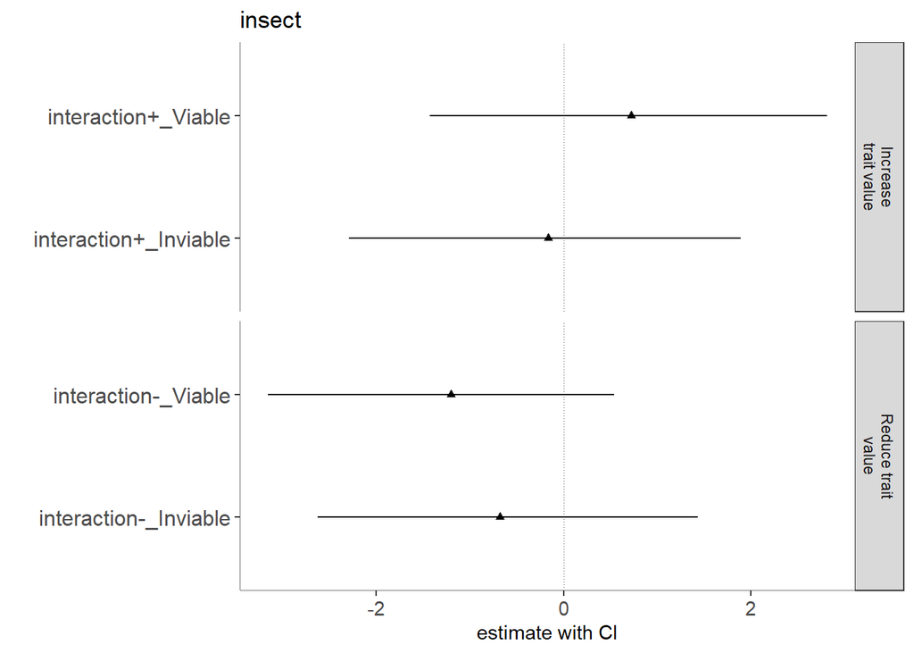

from

to

upper

lower

sign

direction-_Inviable

direction-_Viable

3.182

-1.976

direction-_Inviable

direction+_Inviable

1.644

-3.205

direction-_Inviable

direction+_Viable

1.012

-4.531

direction-_Viable

direction+_Inviable

1.171

-3.396

direction-_Viable

direction+_Viable

-0.583

-3.547

direction+_Inviable

direction+_Viable

1.371

-3.049

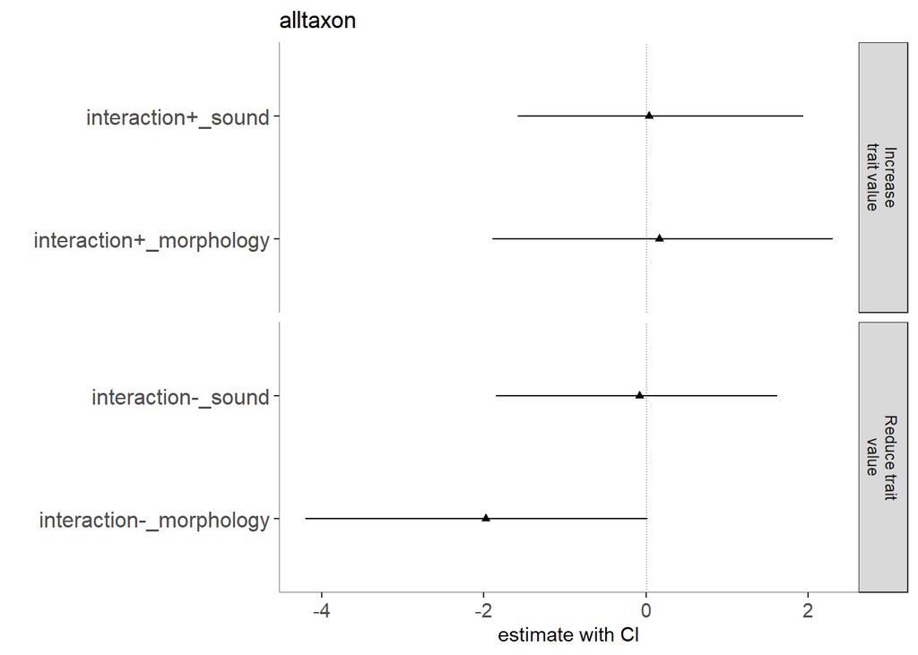

from

to

upper

lower

sign

direction-_morphology

direction-_sound

0.408

-4.887

direction-_morphology

direction+_morphology

-0.230

-4.109

direction-_morphology

direction+_sound

0.842

-4.481

direction-_sound

direction+_morphology

1.891

-2.789

direction-_sound

direction+_sound

0.687

-0.866

direction+_morphology

direction+_sound

2.503

-2.092

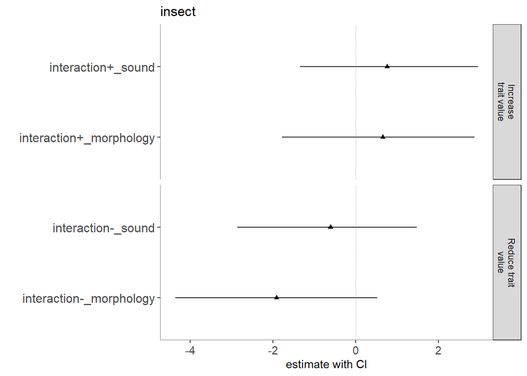

from

to

upper

lower

sign

direction-_morphology

direction-_sound

2.461

-4.604

direction-_morphology

direction+_morphology

-0.389

-5.045

direction-_morphology

direction+_sound

0.673

-5.849

direction-_sound

direction+_morphology

2.164

-4.163

direction-_sound

direction+_sound

-0.063

-3.036

direction+_morphology

direction+_sound

2.745

-3.307